# HCI - Reading Notes

## Week 1

### MacKenzie, I.S. (2013). Chapter 1: Historical Context. Human-Computer Interaction: An Empirical Research Perspective.

- predecessor to HCI is *human factors* or *ergonomics*
- concerned with human capabilities, limitation, performance, and designs that fit within these params
- HCI is narrowing this definition to human interaction with computing technology

#### Historical Context

- "As we may think", Vannevar Bush - *memex* ("associative thinking"), connect points of interest. ie. hyperlink/bookmarks.
- Ivan Sutherland's Sketchpad - manipulation of geometric shapes and lines (objects) on a display using a light pen. Significance: direct manipulation of the interface.
- Invention of the mouse (1964) - Invented by Douglas Engelbart. Direct manipulation on screen. Require "on-screen tracker" to establish correspondence between device space and display space.
  - Other devices, joystick, lightpen, knee-controlled lever, "grafacon". Evaluation, mouse is most accurate, knee-lever is fastest.
- Xerox star (1981) - first commercially released computer system with a GUI. It had windows, icons, menus, and a pointing device (WIMP). It supported direct manipulation and what-you-see-is-what-you-get (WYSIWYG) interaction.
  - Breaks from CLIs, which use a *sequential programming* paradigm.
  - Direct manipulation requires different approach. Uses *event-driven programming*.
- Birth of HCI (1983) - Three key events as markers: the first ACM SIGCHI conference, the publication of Card, Moran, and Newell’s The Psychology of Human-Computer Interaction (1983), and the arrival of the Apple Macintosh, pre-announced with flyers in December 1983
  - ACM SIGCHI conference - association of professionals who work in the research and practice of computer-human interaction
  - "Psychology of human-computer interaction", Card, Moran, Newel - Concepts, *human perceptual input* (e.g., the time to visually perceive a stimulus), *cognition* (e.g., the time to decide on the appropriate reaction), and *motor output* (e.g., the time to react and move the hand or cursor to a target).
    - Significance: Theory for designers of interfaces. "Convincingly demonstrates why and how models are important and to teach us how to build them."
    - Context is the milieu of basic research in human-computer interaction and related fields.
    - "Whether generating quanti- tative predictions across alternative design choices or delimiting a problem space to reveal new relationships, a model’s purpose is to tease out strengths and weak- nesses in a hypothetical design and to elicit opportunities to improve the design."
  - Apple Macintosh - like Xerox Star, but catered to masses.

#### Growth of GUIs

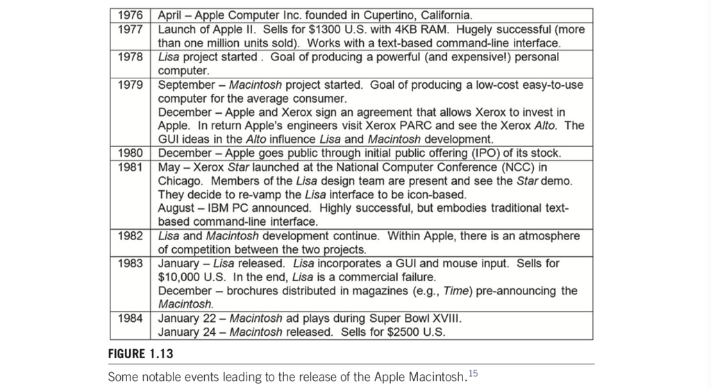

#### Growth of HCI Research

Early topics:

- Quality, effectiveness, and efficiency of the interface. How quickly and accurately can people do common tasks using a GUI versus a text-based command-line interface?
- Menu design - recognition (selecting a command) vs recall (typing), depth vs breadth.

### Norman, D. (2013). Chapter 1: The Psychopathology of Everyday Things

Two of the most important characteristics of good design are discoverability and understanding

1. Discoverability: Is it possible to even figure out what actions are possible and where and how to perform them?
2. Understanding: What does it all mean? How is the product supposed to be used? What do all the different controls and settings mean?

#### Fields of design:

1. Industrial design: The professional service of creating and developing concepts and specifications that optimize the function, value, and appearance of products and systems for the mutual benefit of both user and manufacturer (from the Industrial Design Society of America’s website).
2. Interaction design: The focus is upon how people interact with technology. The goal is to enhance people’s understanding of what can be done, what is happening, and what has just occurred. Interaction design draws upon principles of psychology, design, art, and emotion to ensure a positive, enjoyable experience.
3. Experience design: The practice of designing products, processes, services, events, and environments with a focus placed on the quality and enjoyment of the total experience.

> *"We must design our machines on the assumption that people will make errors."*

#### The role of HCD and Design Specializations

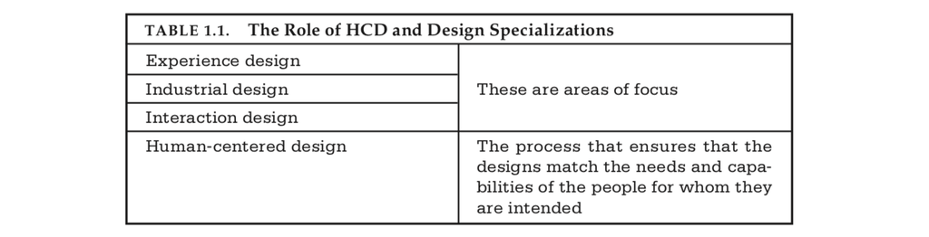

- Starting with a good understanding of people and the needs that the design is intended to meet.
- Getting the specification of the thing to be defined is one of the most difficult parts of the design, so much so that the HCD principle is to avoid specifying the problem as long as possible but instead to iterate upon repeated approximations.

#### Fundamental Principles of Interaction

- Discoverability results from appropriate application of five fundamental psychological concepts covered in the next few chapters: affordances, signifiers, constraints, mappings, and feedback.
- But there is a sixth principle: the conceptual model of the system. It is the conceptual model that provides true understanding

#### Affordance

- The term affordance refers to the relationship between a physical object and a person.
- An affordance is a relationship between the properties of an object and the capabilities of the agent that determine just how the object could possibly be used. E.g. chair affords ("is for") support, and therefore, affords sitting.
- Affordances exist even if they are not visible. For designers, their visibility is critical: visible affordances provide strong clues to the operations of things

#### Signifiers

- Signifiers: If an affordance or anti-affordance cannot be perceived, some means of signaling its presence is required
- Signifier refers to any mark or sound, any perceivable indicator that communicates appropriate behavior to a person.
- Clarification: A sign is NOT an affordance, it is a signifier.
- Can be delibarte ("PUSH" sign) or unintentional (newly created path by humans).

Affordance vs Signifiers:

- Affordances are the possible interactions between people and the environment. Some affordances are perceivable, others are not.
- Perceived affordances often act as signifiers, but they can be ambiguous.
- Signifiers signal things, in particular what actions are possible and how they should be done. Signifiers must be perceivable, else they fail to function.

Mapping: When the mapping uses spatial correspondence between the layout of the controls and the devices being controlled, it is easy to determine how to use them

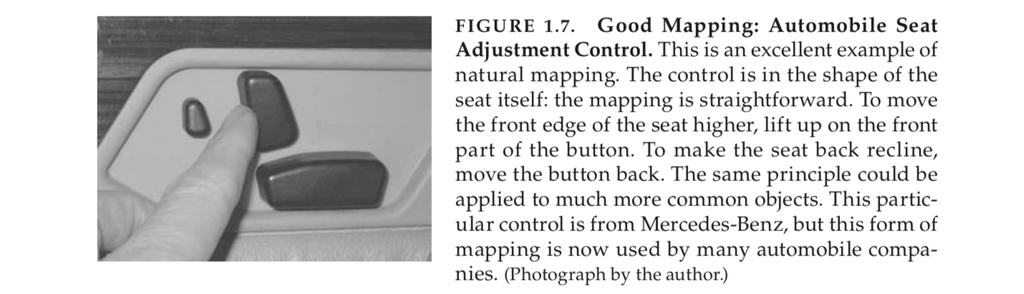

Feedback

- Requirements: immediate, informative, just the right amount.

Conceptual Models

- A conceptual model is an explanation, usually highly simplified, of how something works.
- It doesn’t have to be complete or even accurate as long as it is useful.
- Can be explained to user, or learned by experience.
- Bad design: When controls suggest a false conceptual model (e.g. refrigerator with 2 controls for freezer / fridge, but are both affected by either control).

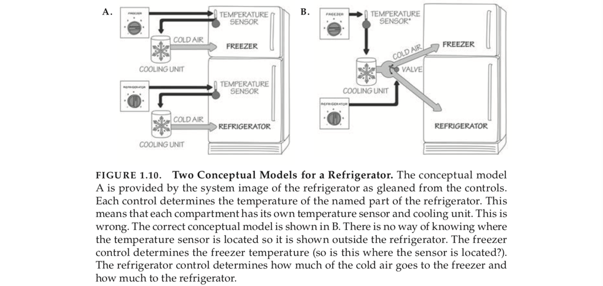

#### System Image

Definition: The system image is what can be derived from the physical structure that has been built (including documentation).

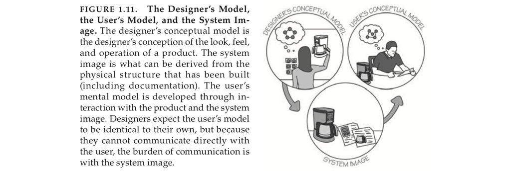

### Norman, D. A. (1986). Cognitive engineering.

Goals:

1. To understand the fundamental principles behind human action and performance that are relevant for the development of engineering principles of design.
2. To devise systems that are pleasant to use - the goal is neither efficiency nor ease nor power, although these are all to be desired, but rather systems that are pleasant, even fun

Psychological Variables Differ From Physical Variables: In many situations, the variables easily controlled are not those that the user cares about.

1. Mapping problems: Which control controls what?
2. Ease of control
3. Evaluation - determine if correct outcome has been reached.

#### Gulf of Execution / Evaluation

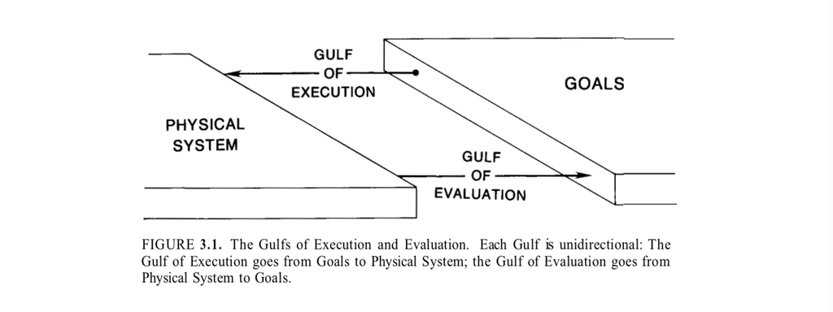

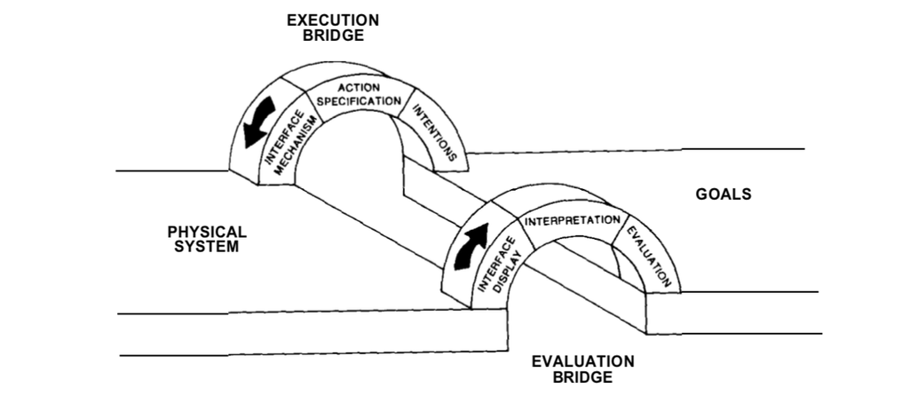

## Week 2

## Week 3

## Week 4

## Week 5

## Week 6

## Week 7

## Week 8

## Week 9

## Week 10